# Multiple Qubit Quantum Systems

Author: Sriram Sankaranarayanan, University of Colorado Boulder, srirams@colorado.edu

$$\newcommand\ket[1]{\left| #1 \right\rangle}$$

Thus far, we have seen how single qubits can exist as superpositions of pure states $\ket{0}$ and $\ket{1}$:

$$ \ket{\psi} = \alpha \ket{0} + \beta \ket{1}\,,$$

wherein $\alpha, \beta$ are complex numbers so that $|\alpha|^2 + |\beta|^2 = 1$. We also saw that measuring $\ket{\psi}$ causes the super-position to collapse to one of the pure-states: $\ket{0}\ \text{with probability}\ |\alpha|^2 \ \text{and}\ \ket{1}\ \text{with probability}\ |\beta|^2$.

We can now extend from single qubit to multiple qubit systems. Classically, we consider multiple bits as represented by multiple wires in the circuit each carrying a voltage that is interpreted as a zero/one OR multiple `flip-flop` circuits (basic units of memory in digital circuits) that are each set to the zero/one state. In a quantum system, a multiple qubit system is composed of multiple trapped ions or superconducting quantum dots that are placed in close proximity to each other and isolated from the rest of the world while not from each other.

Suppose individual qubits are expressed as superpositions of pure-states $\ket{0}, \ket{1}$. A two qubit quantum system is written in a basis consisting of four pure-states $\ket{00}, \ket{01}, \ket{10}, \ket{11}$. Each of these "ket"s represents a pure state which provides values for each of the two qubits. For instance, $\ket{01}$ indicates that the first qubit is in state $\ket{0}$ and the second qubit is in state $\ket{1}$. Therefore, a two qubit quantum system can be written as a superposition $$\ket{\xi} = \alpha_1 \ket{00} + \alpha_2 \ket{01} + \alpha_3 \ket{10} + \alpha_4 \ket{11}$$ such that $|\alpha_1|^2 + |\alpha_2|^2 + |\alpha_3|^2 + |\alpha_4|^2 = 1$. Such a state upon measurement, yields one of four possibility:

$$\left\{ \begin{array}{cc} \ket{00} & \mathsf{with\ prob.}\ |\alpha_1|^2 \\ \ket{01} & \mathsf{with\ prob.}\ |\alpha_2|^2 \\ \ket{10} & \mathsf{with\ prob.}\ |\alpha_3|^2 \\ \ket{11} & \mathsf{with\ prob.}\ |\alpha_4|^2 \\ \end{array}\right.$$

Mathematically, we can combine multiple qubits into a single state through an operation that is called a tensor product or a direct product.

## Direct/Tensor Product

Given two qubits that are each in a superposition $\ket{\varphi}$ and $\ket{\psi}$ respectively, their direct or tensor product is denoted $\ket{\varphi} \otimes \ket{\psi}$ represents a single quantum state that is made up of these two qubits. Suppose

$$\ket{\varphi} = \alpha_1 \ket{0} + \beta_1 \ket{1},\ \ket{\psi} = \alpha_2 \ket{0} + \beta_2 \ket{1}$$

then their direct product is given by

$$\ket{\varphi} \otimes \ket{\psi} = \alpha_1 \alpha_2 \ket{0} \otimes \ket{0} + \beta_1 \alpha_2 \ket{1} \otimes \ket{0} + \alpha_1 \beta_2 \ket{0} \otimes \ket{1} + \beta_1 \beta_2 \ket{1} \otimes \ket{1} \,.$$

The notation $\ket{00}$ is therefore equivalent to $\ket{0} \otimes \ket{0}$ and likewise for the other tensor product of pure states. We will often write $\ket{\varphi}\ket{\psi}$ or even $\ket{\varphi \psi}$ as equivalent notation to $\ket{\varphi} \otimes \ket{\psi}$.

If we represent a super position as vectors: $\ket{\varphi} = \left( \begin{array}{c} \alpha_1 \\ \beta_1 \\ \end{array} \right)$ and $\ket{\psi} = \left( \begin{array}{c} \alpha_2 \\ \beta_2 \\ \end{array} \right)$ over the basis $\ket{0}, \ket{1}$, then $$ \ket{\varphi} \otimes \ket{\psi} = \left( \begin{array}{c} \alpha_1 \left(\begin{array}{c} \alpha_2 \\ \beta_2 \\ \end{array}\right) \\ \beta_1 \left(\begin{array}{c} \alpha_2 \\ \beta_2 \\ \end{array}\right)\end{array} \right) = \left( \begin{array}{c} \alpha_1 \alpha_2 \\ \alpha_1 \beta_2 \\ \beta_1 \alpha_2 \\ \beta_1 \beta_2 \\ \end{array}\right) \ \text{over the basis}\ \ket{00}, \ket{01}, \ket{10} , \ket{11} $$

Note that the direct product distributes over super-positions: $$ \ket{\varphi} \otimes ( \alpha \ket{\psi_1} + \beta \ket{\psi_2} ) = \alpha \ket{\varphi}\otimes \ket{\psi_1} + \beta \ket{\varphi} \otimes \ket{\psi_2}\,,$$ $$ ( \alpha \ket{\psi_1} + \beta \ket{\psi_2} ) \otimes \ket{\varphi} = \alpha \ket{\psi_1}\otimes \ket{\varphi} + \beta \ket{\psi_2} \otimes \ket{\varphi}\,,$$

## Entangled Qubits

Not all two qubit states can be written as a direct product of super positions: this fact has enormous implications. Consider the famous Bell state: $\frac{1}{\sqrt{2}}\left( \ket{00} + \ket{11}\right)$.

**Lemma:** The Bell state above cannot be written as a tensor product of two single qubits: $\ket{\varphi} \otimes \ket{\psi}$.

**Proof** Assume that the Bell state can infact be written as a tensor product.

$$\frac{1}{\sqrt{2}}\left( \ket{00} + \ket{11}\right) = \ket{\varphi} \otimes \ket{\psi}\,.$$

Assume: $$\ket{\varphi} = \alpha_1 \ket{0} + \beta_1 \ket{1},\ \ket{\psi} = \alpha_2 \ket{0} + \beta_2 \ket{1}$$ then their direct product is given by $$\ket{\varphi} \otimes \ket{\psi} = \alpha_1 \alpha_2 \ket{0} \otimes \ket{0} + \beta_1 \alpha_2 \ket{1} \otimes \ket{0} + \alpha_1 \beta_2 \ket{0} \otimes \ket{1} + \beta_1 \beta_2 \ket{1} \otimes \ket{1} \,.$$

Setting this equal to the Bell state, we obtain that $\beta_1 \alpha_2 = 0$ and $\alpha_1 \beta_2 = 0$. This means that one of $\{\alpha_2, \beta_1\}$ must be zero and one of $\{\beta_2, \alpha_1\}$ must be zero. However, we also require that $\alpha_1 \alpha_2 = \beta_1 \beta_2 = \frac{1}{\sqrt{2}}$. This yields a contradiction since if $\alpha_1 \alpha_2 \not= 0$ then both $\beta_1, \beta_2$ must be zero. **QED**

A multi-qubit state $\ket{\xi}$ that cannot be written as a tensor product $\ket{\varphi_1} \otimes \ket{\varphi_2} \cdots \otimes \ket{\varphi_n}$ of single qubit states is said to be entangled.

The possibility of entanglements in quantum mechanics was first proposed by Einstein, Podolsky and Rosen as a thought experiment in order to show that the postulates of quantum mechanics can yield physically counter-intuitive consequences. They imagine two particles emitted simultaneously in opposite directions by a single atom that stays stationary after emitting them. If we measure the position of one of them precisely, then we know the position of the other. Likewise, if we measure the velocity (or momentum) of the other particle, we know the momentum of the first one. By measuring position of one of the particles and simultaneously the momentum of the other, we can seemingly "cheat" the uncertainty principle that says that position and momentum of a particle cannot be measured with accuracy at the same time (actually the uncertainty principle says something much more far reaching). To get around this contradiction, it was suggested that the two particles are *entangled*. Measurement of position on one, makes the momentum of the other photon completely uncertain.

Likewise, the Bell state represents an entanglement of the two qubits.

- Suppose we measured just the first qubit, without measuring the second one. With probability $\frac{1}{2}$ it collapses a $\ket{0}$ and a $\ket{1}$ with probability $\frac{1}{2}$.
- However, if the first qubit collapses to a $\ket{0}$ state, the second qubit must collapse to a $\ket{0}$ state (similarly for $\ket{1}$ state). This happens even though we did not measure the second qubit explicitly. Entanglements are a fundamental feature of quantum computing. It is argued that without entanglement, the power of quantum computing is strictly decreased.

In general, measurement of one qubit in an entanglement can cause a collapse of the second qubit to a superposition. Consider the super-position:

$$\frac{1}{2} \ket{00} + \frac{1}{2} \ket{01} + \frac{1}{\sqrt{2}}\ket{11} $$

Let us call the first qubit $b_1$ and the second qubit $b_2$. Measuring $b_1$ yields a $\ket{0}$ with probability given by $\frac{1}{2}$. This is because, there are two states in the superposition for which the first qubit is in $\ket{0}$: $\ket{00}, \ket{01}$ each with amplitude $\frac{1}{2}$. Measurement thus yields $\ket{0}$ with probability $\frac{1}{4} + \frac{1}{4} = \frac{1}{2}$, and the same probability for $\ket{1}$. What happens to the second qubit?

If the first qubit upon (partial) measurement yields a $\ket{0}$, then the second qubit collapses to the state: $\frac{1}{\sqrt{2}} (\ket{0} + \ket{1})$ and likewise, if the first qubit yields a $\ket{1}$ upon measurement, the second qubit collapses to the pure state $\ket{1}$.

### Multi-Qubit Quantum Systems

In general, 3 qubit states are generated by the basis $\ket{000}, \ket{001}, \ket{010}, \ket{011}, \ket{100}, \ket{101}, \ket{110}, \ket{111}$ consisting of $8$ pure three qubit basis states.

A $n$ qubit quantum system has $2^n$ basis states given by all possible Boolean combinations of $n$ bits.

## Multi-Qubit Gates

We will now talk about quantum operations on multi-qubit systems. In general, a multi-qubit quantum gate is described by a unitary operator $W$ that operates on a superposition $ \alpha_1 \ket{00} + \alpha_2 \ket{01} +\alpha_3 \ket{10} + \alpha_4 \ket{11}$ to yield a new super position $\alpha'_1 \ket{00} + \alpha'_2 \ket{01} +\alpha'_3 \ket{10} + \alpha'_4 \ket{11}$. Fixing the basis to $\ket{00}, \ket{01}, \ket{10}, \ket{11}$, we can represent $W$ as a $4 \times 4$ matrix so that :

$$\left( \begin{matrix} \alpha'_1 \\ \alpha'_2 \\ \alpha'_3 \\ \alpha'_4 \\ \end{matrix} \right) = W \times \left( \begin{matrix} \alpha_1 \\ \alpha_2 \\ \alpha_3 \\ \alpha_4 \\ \end{matrix} \right)$$

Similarly, quantum operations on 3 qubit systems will form operators that are represented by $8 \times 8$ matrices and $k$ qubit systems by $2^k \times 2^k$ operators.

We imagine these operators being mapped on to physical actions such as subjecting a bunch of trapped ions to a laser pulse of specific frequencies and durations that implement the unitary transformation. However, physically it is not possible to operate on too many qubits at the same time. Therefore, we study operators on multiple qubits that are "built up" from simpler operations involving one, two or (at most) three qubits at a time.

### Direct (Tensor) Products of Single Qubit Operations

For a multi-qubit system, composed of individual qubits $b_1, \ldots, b_n$, one can perform any single qubit (unitary) operation on a given qubit $q_i$.

For example, consider the two qubit state $\ket{00}$. Suppose we applied a Hadamard gate on the second qubit. Recall $ \ket{0} \xrightarrow{H} \frac{1}{\sqrt{2}} (\ket{0} + \ket{1})$. Applying the Hadamard gate to the second qubit results in

$$\ket{0} \otimes (H \ket{0}) = \ket{0} \otimes \frac{1}{\sqrt{2}} (\ket{0} + \ket{1}) = \frac{1}{\sqrt{2}}( \ket{00} + \ket{01})$$

We can write the operation above as the direct product between $I \otimes H$ where $I$ is the identity operator and $H$ is the Hadamard operator. The direct product between the single qubit operators creates a two qubit operator $I \otimes H$ that applies $I$ to the first qubit and $H$ to the second qubit.

In general, we have for any two unitary operators on single qubits,

$$ (U_1 \otimes U_2 ) (\ket{\varphi_1} \otimes \ket{\varphi_2}) = (U_1 \ket{\varphi_1}) \otimes (U_2 \ket{\varphi_2})$$

Let $U,V$ be two unitary operators represented by matrices that we will also call $U,V$. Let $U_{ij}$ ($V_{ij}$) be the $i \times j$ entry of matrix $U$($V$).

The operator $W = U \otimes V$ can be expressed as a $4\times 4$ matrix over the basis $\ket{00}, \ket{01}, \ket{10}, \ket{11}$ as

$$W =\left[\begin{matrix} U_{11} \left[\begin{matrix} V_{11} & V_{12} \\ V_{21} & V_{22} \\ \end{matrix} \right] & U_{12} \left[\begin{matrix} V_{11} & V_{12} \\ V_{21} & V_{22} \\ \end{matrix} \right] \\ U_{21} \left[\begin{matrix} V_{11} & V_{12} \\ V_{21} & V_{22} \\ \end{matrix} \right] & U_{22} \left[\begin{matrix} V_{11} & V_{12} \\ V_{21} & V_{22} \\ \end{matrix} \right] \\ \end{matrix}\right] = \left[\begin{matrix} U_{11}V_{11} & U_{11}V_{21} & U_{21}V_{11} & U_{21}V_{21}\\ U_{11}V_{12} & U_{11} V_{22} & U_{21}V_{12} & U_{21} V_{22}\\ U_{12}V_{11} & U_{12} V_{21} & U_{22}V_{11} & U_{22} V_{21} \\ U_{12}V_{22} & U_{12} V_{22} & U_{22}V_{22} & U_{22} V_{22}\\ \end{matrix}\right]$$

## Creating the Uniform superposition

The uniform superposition of two qubits is given by $\ket{u} = \frac{1}{2} ( \ket{00} + \ket{01} + \ket{10} + \ket{11})$. It yields each of the four possible pure states with equal probability. How do we create such a super-position?

In general, it is possible to initialize a qubit into its ground or $\ket{0}$ state. Therefore, we can independently ensure that our two qubit system is initialized to $\ket{00}$ state. What unitary operator do we apply to obtain the $\ket{u}$ state?

Apply a Hadamard gate to each qubit or in other words, apply the operator $U = H \otimes H$ to the two qubit system. $$ (H \ket{0}) \otimes (H \ket{0}) = \frac{1}{\sqrt{2}} ( \ket{0} + \ket{1}) \otimes \frac{1}{\sqrt{2}} ( \ket{0} + \ket{1}) = \frac{1}{2} ( \ket{00} + \ket{01} + \ket{10} + \ket{11})$$ More generally for a $k$ qubit system initialized to the state $\ket{0\cdots 0}$, applying the Hadamard operator to each qubit independently or the operator $U = H \otimes H \cdots \otimes H = H^{\otimes k}$ yields a uniform super-position of $2^k$ states. We will use this trick quite often.

```
 	 Probability of |00> : 0.2529 Probability of |01> : 0.2529
 	 Probability of |10> : 0.245 Probability of |11> : 0.253
```

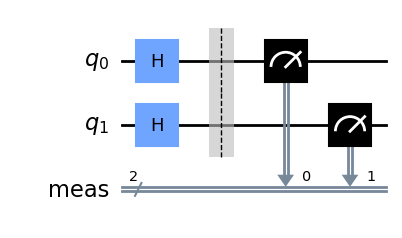

```python
# modified from IBM Qiskit tutorial: https://github.com/Qiskit/qiskit
import numpy as np
from qiskit import QuantumCircuit
from qiskit.primitives.sampler import Sampler
qc1 = QuantumCircuit(2)# A quantum circuit with a two qubits. Qubits are indexed starting from 0
qc1.h(0) # apply hadamard on qubit # 0
qc1.h(1) # apply hadamard on qubit # 1
# 2. Measure all the qubits
qc_measured = qc1.measure_all(inplace=False)

# 3. Execute the circuit using sampler.

sampler = Sampler()
job = sampler.run(qc_measured, shots=10000)# simulate the measurement circuit 10,000 times
result = job.result() # get the result from the simulations
print(f" \t Probability of |00> : {result.quasi_dists[0][1]} Probability of |01> : {result.quasi_dists[0][1]} \n \t Probability of |10> : {result.quasi_dists[0][2]} Probability of |11> : {result.quasi_dists[0][3]} ")
qc_measured.draw('mpl')
```

```
Probability of |0>: 0.06
Probability of |1>: 0.0619
Probability of |2>: 0.0632
Probability of |3>: 0.0646
Probability of |4>: 0.0643
Probability of |5>: 0.0657
Probability of |6>: 0.0601
Probability of |7>: 0.0604
Probability of |8>: 0.0644
Probability of |9>: 0.0613
Probability of |10>: 0.0633
Probability of |11>: 0.0648
Probability of |12>: 0.0611
Probability of |13>: 0.0594
Probability of |14>: 0.0642
Probability of |15>: 0.0613
```

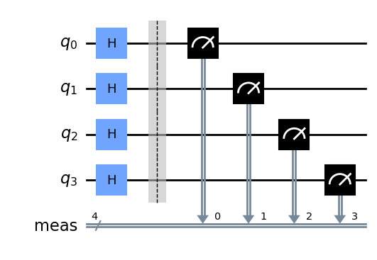

```python
# modified from IBM Qiskit tutorial: https://github.com/Qiskit/qiskit
import numpy as np
from qiskit import QuantumCircuit
from qiskit.primitives.sampler import Sampler
qc1 = QuantumCircuit(4)# A quantum circuit with a four qubits. Qubits are indexed starting from 0
qc1.h(0) # apply hadamard on qubit # 0
qc1.h(1) # apply hadamard on qubit # 1
qc1.h(2) # apply hadamard on qubit # 2
qc1.h(3) # apply hadamard on qubit # 3
# 2. Measure all the qubits
qc_measured = qc1.measure_all(inplace=False)

# 3. Execute the circuit using sampler.

sampler = Sampler()
job = sampler.run(qc_measured, shots=10000)# simulate the measurement circuit 10,000 times
result = job.result() # get the result from the simulations
for i in range(16):
    print(f'Probability of |{i}>: {result.quasi_dists[0][i]}')
qc_measured.draw('mpl')
```

## Controlled Gates

Note that individual qubit operations are limited. For instance, we can never create a Bell state $\frac{1}{\sqrt{2}} ( \ket{00} + \ket{11})$ starting from the two qubit state $\ket{00}$ just by single qubit operations. To create entanglements, we need operators that can actually, well, *entangle*!

Consider that we have a two qubit quantum system $\ket{\varphi}$. Our goal is to apply a unitary operation $U$ to the second qubit only if the first qubit is a $\ket{1}$. Otherwise, if the first qubit is a $\ket{0}$, we leave the second qubit unchanged. This yields a unitary operator $CU$ (controlled-U) that roughly works as follows:

$$CU \ket{b_1 b_2} = \begin{cases} \ket{b_2} & b_1 = 0 \\ U \ket{b_2} & b_1 = 1\\ \end{cases}$$

Note that the first qubit remains unchanged. It is simply the "control qubit" that influences the operation applied to the other qubit.

Consider for instance the Pauli-X ("quantum not" gate) as a single qubit operator that transformed $\ket{0} \xrightarrow{X} \ket{1}$ and $\ket{1} \xrightarrow{X} \ket{0}$. Its two qubit controlled version is given as follows. If the first qubit is $\ket{0}$, leave the second qubit unchanged. Therefore, $$ \ket{00} \xrightarrow{CX} \ket{00},\ \ket{01} \xrightarrow{CX} \ket{01}$$ However, if the first qubit is a $\ket{1}$, apply the $X$ operation on the second qubit: $$ \ket{10} \xrightarrow{CX} \ket{11},\ \ket{11} \xrightarrow{CX} \ket{10}$$

For a single qubit unitary operator $U$, the controlled operator with the first qubit as control bit and second qubit as the bit being operated on, yields a controlled two qubit operator $CU$ with the following matrix in the basis $\ket{00}, \ket{01}, \ket{10}, \ket{11}$:

$$CU = \left( \begin{matrix} 1 & 0 & 0 & 0 \\ 0 & 1 & 0 & 0 \\ 0 & 0 & U_{11} & U_{12} \\ 0 & 0 & U_{21} & U_{22} \\ \end{matrix} \right) = \left( \begin{matrix} I_{2 \times 2} & 0_{2\times 2} \\ 0_{2\times 2} & U \end{matrix}\right)\,.$$

Here $I_{2\times 2}$ is the identity matrix and $0_{2\times 2}$ is the matrix of all zeros.

### Creating the Bell-State

We can now create the Bell-state using the Controlled-X gate.

- Initialize two qubits to the $\ket{00}$ state.
- Apply the Hadamard operator to the first qubit : $\frac{1}{\sqrt{2}}( \ket{00} + \ket{10})$.
- Apply a CX operator to the second qubit with first qubit as control: $\frac{1}{\sqrt{2}}( \ket{00} + \ket{11})$.

```
Probability of |0>: 0.5039
Probability of |1>: 0
Probability of |2>: 0
Probability of |3>: 0.4961
```

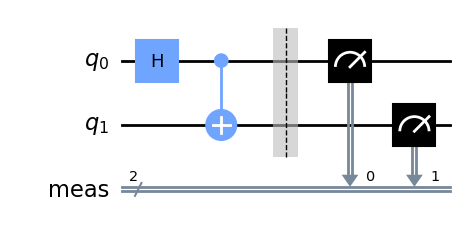

```python
# modified from IBM Qiskit tutorial: https://github.com/Qiskit/qiskit
import numpy as np
from qiskit import QuantumCircuit
from qiskit.primitives.sampler import Sampler
qc1 = QuantumCircuit(2)# A quantum circuit with a four qubits. Qubits are indexed starting from 0
qc1.h(0) # apply hadamard on qubit # 0
qc1.cx(0, 1)# apply control-X with 0 as the control bit and 1 as the bit being operated on
qc_measured = qc1.measure_all(inplace=False)
sampler = Sampler()
job = sampler.run(qc_measured, shots=10000)# simulate the measurement circuit 10,000 times
result = job.result() # get the result from the simulations
distrib = result.quasi_dists[0] # extract the distributions for various measurements froms samples.
for i in range(4):
    if i in distrib:
        print(f'Probability of |{i}>: {distrib[i]}')
    else:
        print(f'Probability of |{i}>: 0')
qc_measured.draw('mpl')
```

Notice the symbol for a control-X gate above. We place a "+" on the second wire indicating that we are operating on it with a X gate and a "." on the control wire indicating that we are using it as a control. Another useful gate is the controlled phase gate. Recall the phase gate:

$$ \ket{0} \xrightarrow{P_{\phi}} \ket{0},\; \ket{1} \xrightarrow{P_{\phi}} e^{i\phi} \ket{1} $$

The control phase gate applies a phase on a qubit based on the value of the control qubit. Suppose we created the Bell-state super position above and applied a controlled phase of $\frac{\pi}{2}$ to the first qubit using the second qubit as control.

$$\frac{1}{\sqrt{2}}( \ket{00} + \ket{11}) \xrightarrow{CP_{\frac{\pi}{2}}} \frac{1}{\sqrt{2}}( \ket{00} + i \ket{11}) $$

Controlled phase gates will be very useful in constructing circuits for quantum Fourier transform (the quantum analog of FFT) that we will study in the next module.

```
(0.71+0.00j) |00> + (0.00+0.00j) |01> + (0.00+0.00j) |10> + (0.00+0.71j) |11>
Note: python uses j = sqrt(-1)
```

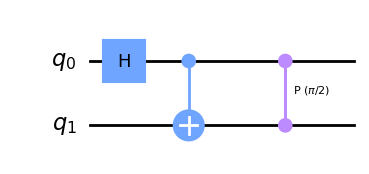

```python
# modified from IBM Qiskit tutorial: https://github.com/Qiskit/qiskit
import numpy as np
from qiskit import QuantumCircuit, Aer, execute

qc1 = QuantumCircuit(2)# A quantum circuit with a four qubits. Qubits are indexed starting from 0
qc1.h(0) # apply hadamard on qubit # 0
qc1.cx(0, 1)# apply control-X with 0 as the control bit and 1 as the bit being operated on
qc1.cp(np.pi/2, 1, 0)
backend = Aer.get_backend('statevector_simulator')
job = execute(qc1, backend)
result = job.result()
statevector = result.get_statevector()
print(f'({statevector[0]:.2f}) |00> + ({statevector[1]:.2f}) |01> + ({statevector[2]:.2f}) |10> + ({statevector[3]:.2f}) |11> ')
print('Note: python uses j = sqrt(-1)')
qc1.draw('mpl')
```

We can have gates controlled by multiple control qubits. The most famous one is called the Tofolli gate, which is a control not gate but with two control qubits. A Tofolli gate operating on bit $b_3$ with control qubits $b_1, b_2$ negates $b_3$ if $b_1, b_2$ are both $\ket{1}$. If either of $b_1, b_2$ are zero, it leaves $b_3$ unchanged.

```
0.71+0.00j|000>+0.00+0.00j|001>+0.00+0.00j|010>+0.00+0.00j|011>+0.00+0.00j|100>+0.00+0.00j|101>+0.00+0.00j|110>+0.71+0.00j|111>
Note: python uses j = sqrt(-1)
```

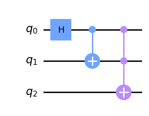

```python
# modified from IBM Qiskit tutorial: https://github.com/Qiskit/qiskit
import numpy as np
from qiskit import QuantumCircuit, Aer, execute

qc1 = QuantumCircuit(3)# A quantum circuit with a three qubits. Qubits are indexed starting from 0
qc1.h(0) # apply hadamard on qubit # 0
qc1.cx(0, 1)# apply control-X with 0 as the control bit and 1 as the bit being operated on
qc1.ccx(0, 1, 2)
backend = Aer.get_backend('statevector_simulator')
job = execute(qc1, backend)
result = job.result()
statevector = result.get_statevector()
def three_qubit_state_vector_to_str(statevector):
    pure_states = [f'|{b1}{b2}{b3}>' for b1 in [0,1] for b2 in [0,1] for b3 in [0,1]]
    state_vectors = [f'{statevector[i]:.2f}' for i in range(8)]
    result_string = '+'.join([f'{s1}{s2}' for (s1, s2) in zip( state_vectors, pure_states)])
    return result_string
print(three_qubit_state_vector_to_str(statevector))
print('Note: python uses j = sqrt(-1)')
qc1.draw('mpl')
```

## No Cloning Theorem

The "no cloning" theorem states that we cannot create a clone/copy of a quantum state. In other words, if $\ket{\psi}$ is an arbitrary quantum state, then we **cannot** make another copy $\ket{\varphi} = \ket{\psi}$ without modifying/destroying the original state.

This sounds rather strange since copying classical states is not that hard. Programming languages have assignment statements `x = y` where the value of `y` gets copied into `x`. As a result, there are two copies of the value that is stored in `y`. However, a quantum superposition cannot be "copied" in the same manner.

**Theorem** There is no unitary operator $U$ such that for all quantum states $\ket{\psi}$ (superpositions of pure states $\ket{0}, \ket{1}$), $U (\ket{\psi} \otimes \ket{0}) = \ket{\psi} \otimes \ket{\psi}$.

The theorem states that we cannot operate on a qubit that is in some state $\ket{\psi}$ that we wish to copy and a fresh qubit prepared in the $\ket{0}$ state using a unitary operator such that the result copies the state of the first qubit over to the second.

**Proof** Let $\ket{\varphi} = \alpha \ket{0} + \beta \ket{1}$ be an arbitrary state. Assume, for the sake of contradiction, that we have

$$ U (\ket{\varphi} \ket{0}) = \ket{\varphi} \otimes \ket{\varphi}\,.$$ However, expanding $\ket{\varphi}$, we may also write $$ \begin{array}{rll} U (\ket{\varphi} \ket{0}) & = U ( \alpha \ket{00} + \beta \ket{10}) \\ & = \alpha U \ket{00} + \beta U \ket{10}\\ & = \alpha \ket{00} + \beta \ket{11} & \because\ U \ket{00} = \ket{00} \ \text{and}\ U \ket{10} = \ket{11} \\ \end{array}$$

However, since $\ket{\varphi}$ is an arbitrary state that we chose, $ \ket{\varphi} \otimes \ket{\varphi} = \alpha^2 \ket{00} + \alpha \beta \ket{01} + \beta \alpha \ket{10} + \beta^2 \ket{11} \not= \alpha \ket{00} + \beta \ket{11}$.

The cloning operator fails to be linear, and thus, unitary. **QED**

It is possible to destructively clone a quantum state. I.e, create a copy of a quantum state but at the cost of destroying the original state. This is called *quantum teleportation* and will be explored later.

## Classical Gates as Quantum Operations

Classically, we build Boolean circuits using AND ($\land$), OR ($\lor$) and NOT ($\neg$) gates. For instance, the AND gate outputs a $1$ if both inputs are $1$ otherwise, it outputs a $0$. Similarly, we can define other gates such as XOR ($\oplus$) in terms of AND, OR and NOT.

We already saw that there is a Quantum NOT gate (the Pauli $X$ operator). However, implementing an AND gate as is for qubits is problematic. For one, the gate has two inputs and one output. Note that unitary operators being invertible (one to one, onto) must also preserve the number of outputs to be equal to that of the inputs. One naive way to achieve this is to have one of the outputs be the AND of the two input qubits and the other output remember one of the inputs. However, this is not invertible and thus, not an operation that we can realize using Quantum gates.

The quantum AND gate is thus defined over three qubits $b_1,b_2, b_3$, two input qubits $b_1, b_2$ and one result qubit $b_3$. The circuit implements the operation: $$ \ket{v_1 v_2 v_3} \xrightarrow{QAND} \ket{v_1 v_2 (v_3 \oplus (v_1 \land v_2))}$$ In other words, for a pure state $\ket{v_1 v_2 v_3}$ wherein $v_1, v_2, v_3 \in \{0, 1\}$, the QAND gate leaves the two input bits unchanged but replaces the result bit by the XOR ($\oplus$) of the old value $v_3$ and the AND of $v_1, v_2$ ($v_1 \land v_2$).

The action of QAND on pure states is given by the following table:

$$\begin{array}{| cc | cc| } \hline \text{Input} & \text{Output} & \text{Input} & \text{Output} \\ \hline \ket{000} & \ket{000} & \ket{001} & \ket{001} \\ \ket{010} & \ket{010} & \ket{011} & \ket{011} \\ \ket{100} & \ket{100} & \ket{101} & \ket{101} \\ \ket{110} & \ket{111} & \ket{111} & \ket{110} \\ \hline \end{array}$$

We can implement QAND using a `CCX` gate (a.k.a Tofolli gate) : https://docs.quantum.ibm.com/api/qiskit/qiskit.circuit.library.CCXGate

```
0.50+0.00j|000> + 0.50+0.00j|100> + 0.50+0.00j|010> + 0.00+0.00j|110> + 0.00+0.00j|001> + 0.00+0.00j|101> + 0.00+0.00j|011> + 0.50+0.00j|111>
Note: python uses j = sqrt(-1)
```

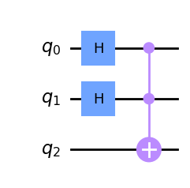

```python
# modified from IBM Qiskit tutorial: https://github.com/Qiskit/qiskit
import numpy as np
from qiskit import QuantumCircuit, Aer, execute

#1. Create a circuit with 3 qubits
qc1 = QuantumCircuit(3)# A quantum circuit with a three qubits. Qubits are indexed starting from 0
#2. Apply a Hadamard to the first twwo qubits to create an uniform superposition
qc1.h(0) # apply hadamard on qubit # 0
qc1.h(1) # apply a hadamard on qubit # 1
# apply a ccx gate and with bits 0, 1 with result bit 2
qc1.ccx(0, 1, 2)
# Let's see what we created
backend = Aer.get_backend('statevector_simulator')
job = execute(qc1, backend)
result = job.result()
statevector = result.get_statevector()
def three_qubit_state_vector_to_str(statevector):
    pure_states = [f'|{b3}{b2}{b1}>' for b1 in [0,1] for b2 in [0,1] for b3 in [0,1]]
    state_vectors = [f'{statevector[i]:.2f}' for i in range(8)]
    result_string = ' + '.join([f'{s1}{s2}' for (s1, s2) in zip( state_vectors, pure_states)])
    return result_string
print(three_qubit_state_vector_to_str(statevector))
print('Note: python uses j = sqrt(-1)')
qc1.draw('mpl')
```

$$ b_1 \lor b_2 \equiv \neg( \neg b_1 \land \neg b_2 )$$

```
0.50+0.00j|000> + 0.00+0.00j|100> + 0.00+0.00j|010> + 0.00+0.00j|110> + 0.00+0.00j|001> + 0.50+0.00j|101> + 0.50+0.00j|011> + 0.50+0.00j|111>
Note: python uses j = sqrt(-1)
```

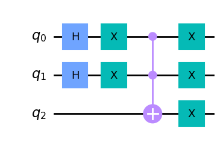

```python
# modified from IBM Qiskit tutorial: https://github.com/Qiskit/qiskit
import numpy as np
from qiskit import QuantumCircuit, Aer, execute

#1. Create a circuit with 3 qubits
qc1 = QuantumCircuit(3)# A quantum circuit with a three qubits. Qubits are indexed starting from 0
#2. Apply a Hadamard to the first twwo qubits to create an uniform superposition
qc1.h(0) # apply hadamard on qubit # 0
qc1.h(1) # apply a hadamard on qubit # 1

# apply not gates to the two inputs
qc1.x(0)
qc1.x(1)
# apply a ccx gate and with bits 0, 1 with result bit 2
qc1.ccx(0, 1, 2)
# negate back the inputs to restore them
qc1.x(0)
qc1.x(1)
# negate the result
qc1.x(2)
backend = Aer.get_backend('statevector_simulator')
job = execute(qc1, backend)
result = job.result()
statevector = result.get_statevector()
def three_qubit_state_vector_to_str(statevector):
    pure_states = [f'|{b3}{b2}{b1}>' for b1 in [0,1] for b2 in [0,1] for b3 in [0,1]]
    state_vectors = [f'{statevector[i]:.2f}' for i in range(8)]
    result_string = ' + '.join([f'{s1}{s2}' for (s1, s2) in zip( state_vectors, pure_states)])
    return result_string
print(three_qubit_state_vector_to_str(statevector))
print('Note: python uses j = sqrt(-1)')
qc1.draw('mpl')
```

**Question:** Can we implement a quantum XOR gate that maps $\ket{v_1 v_2} \rightarrow \ket{v_1 (v_1 \oplus v_2)}$ ?

As it turns out, yes. It is a gate that you have seen before: the controlled-X gate. Also, XOR operator does not need a result qubit since it is unitary.

Consider a classical circuit made up of $k > 0$ logic gates AND, OR and NOT that implements a Boolean function $f(b_1, \ldots, b_m)$ for inputs $b_1, \ldots, b_m$. Any Boolean function can be realized in this way.

We can build an equivalent quantum circuit with input qubits $b_1, \ldots, b_m$, a result qubit $r$ and *ancillary qubits* $q_1, \ldots, q_k$ (as many as the number of logic gates) that implements the operation $$ \ket{b_1 \cdots b_m} \otimes \ket{r} \otimes \underset{\text{ancilla}}{\underbrace{\ket{0\cdots 0}}} \ \longrightarrow\ \ket{b_1 \cdots b_m} \otimes \ket{r \oplus f(b_1, \ldots, b_m)} \otimes \ket{\cdots} \,.$$ Note that the ancillary bits are initialized to $\ket{0}$ at the beginning of the computation and are *ignored* for the rest of the computation. Note that they cannot be measured or otherwise reused under normal conditions.

Suppose we take three qubits $\ket{b_1 b_2} \otimes \ket{0}$ and apply quantum AND to obtain $\ket{b_1 b_2} \otimes \ket{b_1 \land b_2}$. If the result bit is no longer needed at some point in the computation, we may ignore it until the computation is over but not _measure_ it. Since it continues to be entangled with $b_1, b_2$. For instance if we measured it and obtained a $\ket{1}$, then $\ket{b_1 b_2}$ will collapse to $\ket{11}$. For some reason this is not emphasized in many textbooks/notes.

## Example

We would like to implement the Boolean function $$f(b_1, b_2, b_3) = (b_1\ \lor\ \neg b_2)\ \land\ ( b_1\ \lor\ b_2\ \lor\ \neg b_3)$$

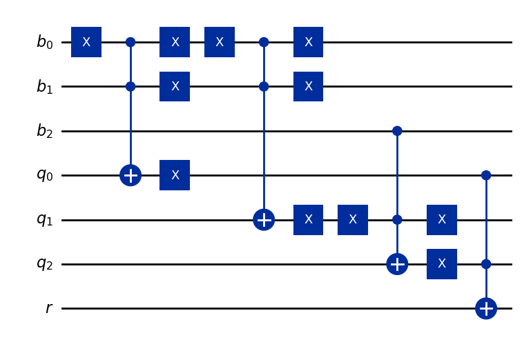

```python
import numpy as np
from qiskit import QuantumCircuit, QuantumRegister

def apply_qor2(q_circuit, bit1_idx, negate_bit1, bit2_idx, negate_bit2, ancilla_idx):
    if not negate_bit1:
        q_circuit.x(bit1_idx)
    if not negate_bit2:
        q_circuit.x(bit2_idx)
    q_circuit.ccx(bit1_idx, bit2_idx, ancilla_idx)
    if not negate_bit1:
        q_circuit.x(bit1_idx)
    if not negate_bit2:
        q_circuit.x(bit2_idx)
    q_circuit.x(ancilla_idx)

def apply_qand2(q_circuit, bit1_idx, bit2_idx, ancilla_idx ):
    q_circuit.ccx(bit1_idx, bit2_idx, ancilla_idx)



#1. Create a circuit with 3 input qubits + three ancillary qubits + one result qubit
inputs = QuantumRegister(3,'b') # input register = 3 qubits
ancilla = QuantumRegister(3, 'q') # ancillary qubits = 3 qubits
res = QuantumRegister(1, 'r') # result = 1 qubit

qc = QuantumCircuit(inputs, ancilla, res)# A quantum circuit with a sevem qubits. Qubits are indexed starting from 0

apply_qor2(qc, inputs[0], False, inputs[1], True, ancilla[0]) # apply b1 \/ ! b2 with result qubit index 3
apply_qor2(qc, inputs[0], False, inputs[1], False, ancilla[1]) # b1 \/ b2 with result quibit 4
apply_qor2(qc, ancilla[1], False, inputs[2], True, ancilla[2]) # previous result or !b3
apply_qand2(qc, ancilla[0], ancilla[2], res[0])
qc.draw('mpl', style="iqp")
```

## Quantum Parallelism

Superpositions of quantum states allow for parallelism. Consider an uniform super position of three qubits:

$$\ket{\psi}:\ \frac{1}{\sqrt{8}} \left( \ket{000} + \ket{001} + \cdots + \ket{111} \right)$$

and the quantum circuit defined above that computes the Boolean function: $$f(b_1, b_2, b_3) = (b_1\ \lor\ \neg b_2)\ \land\ ( b_1\ \lor\ b_2\ \lor\ \neg b_3)$$

If we input the super position $$\ket{\psi} \otimes \underset{\text{ancilla}}{\underbrace{\ket{000}}} \otimes \underset{r}{\underbrace{\ket{0}}}$$

The output of the circuit (ignore the value of ancillary bits) will be a super position of the form

$$\frac{1}{\sqrt{8}} \left( \ket{000}\ket{f(0,0,0)} + \ket{001} \ket{f(0,0,1)} + \cdots + \ket{111}\ket{f(1,1,1)} \right) $$

which is the same as saying the circuit computes the function $f$ in parallel over all the pure states involved in the super position. This is the essence of quantum parallelism.

This also serves to inform us about the key limitation of this type of parallelism: our inability to directly access the components of the super position. If we attempted to measure the qubits after the result, we may obtain one component uniformly at random along with the value computed for it. If we just do a partial measurement of the result qubit, we will obtain a $\ket{0}$ or $\ket{1}$ for the result qubit along with the states $\ket{b_1 b_2 b_3}$ that collapse to the possible inputs that lead to the measured output.

### Example

Quantum parallelism is achieved by evaluating the circuit above using the uniform superposition for the input qubit, which is in turn obtained by using the Hadamard gate on them. Suppose we measure the result qubit, then we either obtain a $\ket{0}$ for the result in which case, the super position collapses to all possible values of $\ket{b_1 b_2 b_3}$ such that $f(b_1, b_2, b_3) = 0$. Similar process happens if the result is $\ket{1}$.

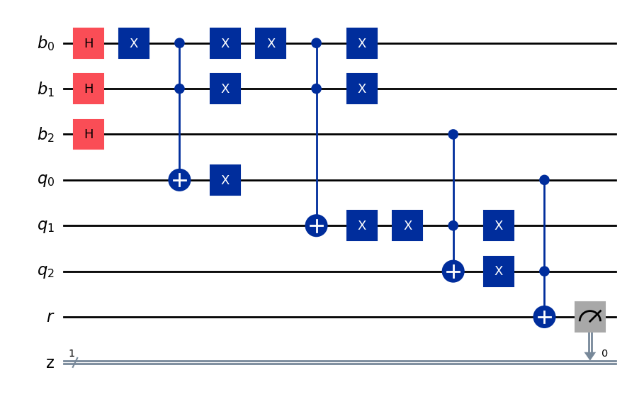

```python
import numpy as np
from qiskit import QuantumCircuit, QuantumRegister, ClassicalRegister,  Aer, transpile
from qiskit.tools.visualization import plot_histogram, plot_state_city

## Copy and paste the circuit from previous example
def apply_qor2(q_circuit, bit1_idx, negate_bit1, bit2_idx, negate_bit2, ancilla_idx):
    if not negate_bit1:
        q_circuit.x(bit1_idx)
    if not negate_bit2:
        q_circuit.x(bit2_idx)
    q_circuit.ccx(bit1_idx, bit2_idx, ancilla_idx)
    if not negate_bit1:
        q_circuit.x(bit1_idx)
    if not negate_bit2:
        q_circuit.x(bit2_idx)
    q_circuit.x(ancilla_idx)

def apply_qand2(q_circuit, bit1_idx, bit2_idx, ancilla_idx ):
    q_circuit.ccx(bit1_idx, bit2_idx, ancilla_idx)


def create_uniform(q_circuit, bits):
    for i in bits:
        q_circuit.h(i) # apply Hadamard gate

#1. Create a circuit with 3 input qubits + three ancillary qubits + one result qubit
inputs = QuantumRegister(3,'b') # input register = 3 qubits
ancilla = QuantumRegister(3, 'q') # ancillary qubits = 3 qubits
res = QuantumRegister(1, 'r') # result = 1 qubit
res_measured = ClassicalRegister(1, 'z') # hold the measurement output
qc = QuantumCircuit(inputs, ancilla, res, res_measured)# A quantum circuit with a sevem qubits. Qubits are indexed starting from 0
create_uniform(qc, [inputs[0], inputs[1], inputs[2]]) # apply hadamard gate
apply_qor2(qc, inputs[0], False, inputs[1], True, ancilla[0]) # apply b1 \/ ! b2 with result qubit index 3
apply_qor2(qc, inputs[0], False, inputs[1], False, ancilla[1]) # b1 \/ b2 with result quibit 4
apply_qor2(qc, ancilla[1], False, inputs[2], True, ancilla[2]) # previous result or !b3
apply_qand2(qc, ancilla[0], ancilla[2], res[0])
qc.measure(res, res_measured)

qc.draw('mpl', style="iqp")
```

[figure not shown]

```python
# Transpile for simulator
simulator = Aer.get_backend('aer_simulator')
circ = transpile(qc, simulator)

# Run and get counts
result = simulator.run(qc).result()
counts = result.get_counts(circ)
plot_histogram(counts, title='result counts (1000 simulations)')
```

How do quantum algorithms exploit this parallelism? The key is to compute classical functions using quantum circuits but then if we are searching for some specific pattern, the goal is to create unitary operations that boost up the amplitude/probability of the patterns we are searchng for while damping down the probability of what we are not interested in.

As an example, suppose we wish to check if a Boolean formula $\varphi$ is satisfiable:

- We encode $\varphi$ as a quantum circuit: $\ket{b_1, \ldots, b_n} \otimes \ket{0} \xrightarrow{U} \ket{b_1, \ldots, b_n} \otimes \ket{\varphi(b_1, \ldots, b_n)}$.
- We somehow boost up the amplitude of those pure states for which $\varphi(b_1, \ldots, b_n) = \mathit{true}$ and damp down the amplitude of the states for which $\varphi(b_1, \ldots, b_n) = \mathit{false}$.
- Once we have done the amplitude modification, we measure and obtain a state $\ket{b_1, \ldots, b_n} $ such that $f(b_1, \ldots, b_n) = 1$ with very high probability.

An algorithm that does precisely this is the Grover search algorithm. We are going to study it next!!